# Take-home Exercise 01

Creating data visualisation beyond default.

Rakendu https://www.linkedin.com/in/rakendu-ramesh/ (Singapore Management University)https://scis.smu.edu.sg/  
2022-04-25

# Overview

In this Take-home exercise, we will apply the skills learnt in Visual Analytics Lesson 1 to reveal the demographics of the City of Engagement, Ohio USA by using appropriate static statistical graphics methods. We will process the data using **tidyverse** family of packages. We will then use **ggplot2** and its extensions to prepare the statistical graphics to understand the demographics of the city of Engagement, Ohio USA.

### Dataset

The dataset used is available for download [*here*](https://vast-challenge.github.io/2022/).

# Step by Step Description

Following are the steps taken to undesrtand the demographics of the region.

## Getting Started

We will first load the required packages using the below code chunk

```r
packages = c('tidyverse','ggdist','gghalves','ggthemes','hrbrthemes','ggridges','patchwork')
for(p in packages){
  if(!require(p, character.only = T)){
    install.packages(p)
  }
  library(p, character.only = T)
}
```

## Importing Data

The code chunk below imports *Participants.csv* from the data folder by using [`read_csv()`](https://readr.tidyverse.org/reference/read_delim.html) function of [**readr**](https://readr.tidyverse.org/index.html) package into R and save it as a tibble dataframe called *participants_data*.

```r
participants_data <- read_csv("data/Participants.csv")
```

### Overview of the data

Lets take a look at the data. Brief glance at the columns available in the Participants data shows that it contains household size, age, education level, have kids and joviality. All these are useful attributes to understand the demographics of a region. Let us look at each of these attributes individually to analyse their usefulness further.

```r
head(participants_data,10,7)
```

```
# A tibble: 10 x 7
   participantId householdSize haveKids   age educationLevel
           <dbl>         <dbl> <lgl>    <dbl> <chr>
 1             0             3 TRUE        36 HighSchoolOrCollege
 2             1             3 TRUE        25 HighSchoolOrCollege
 3             2             3 TRUE        35 HighSchoolOrCollege
 4             3             3 TRUE        21 HighSchoolOrCollege
 5             4             3 TRUE        43 Bachelors
 6             5             3 TRUE        32 HighSchoolOrCollege
 7             6             3 TRUE        26 HighSchoolOrCollege
 8             7             3 TRUE        27 Bachelors
 9             8             3 TRUE        20 Bachelors
10             9             3 TRUE        35 Bachelors
# ... with 2 more variables: interestGroup <chr>, joviality <dbl>
```

### Understanding the distribution of age

The code chunk below creates a histogram of age by using geom_histogram() of ggplot2.From the visualization we can see that the age of the participants ranges from 15 to 60 approximately.

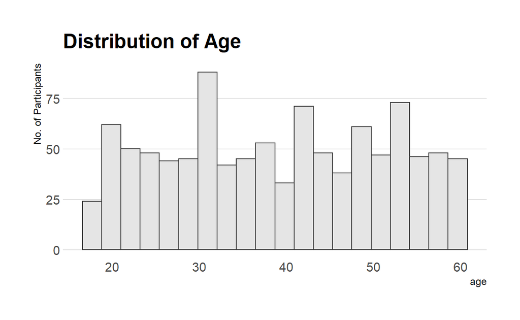

```r
ggplot(data=participants_data,
       aes(x = age)) +
  geom_histogram(bins=20,
                 color = "grey25",
                 fill = "grey90")+
  ggtitle("Distribution of Age")+
  ylab("No. of Participants") +
  theme_ipsum(grid ="Y")
```

To get the definite minimum and maximum age values, let us use a boxplot.

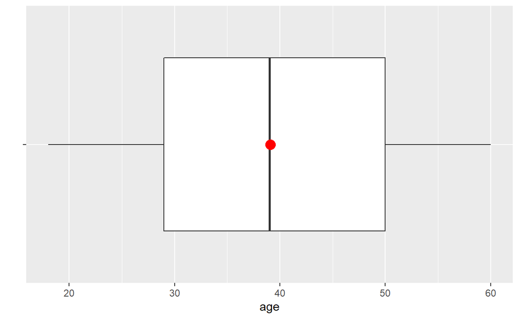

```r
ggplot(data = participants_data,
      aes(y = "", x = age)) +
  geom_boxplot() +
  stat_summary(geom = "point",
              fun = mean,
              colour = "red",
              size = 4) +
  ylab("")
```

Let us further update the age histogram to show the median and mean and use it as the final visualization for age demographic.

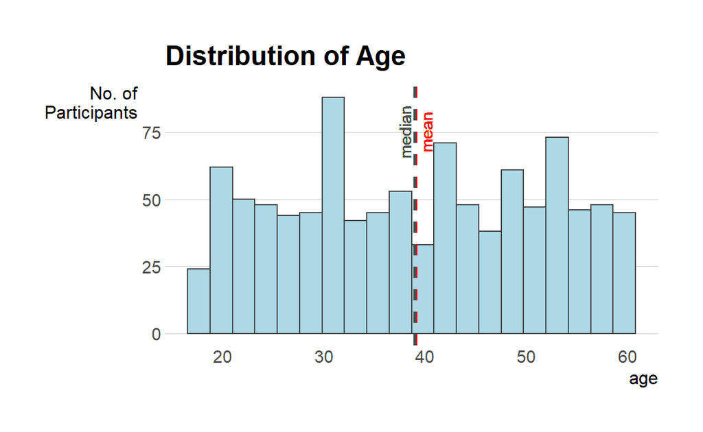

```r
p1 <- ggplot(data=participants_data,
       aes(x = age)) +
  geom_histogram(bins=20,
                 color = "grey25",
                 fill = "light blue")+
  ggtitle("Distribution of Age")+
  ylab("No. of\nParticipants") +
  theme_ipsum(axis_title_size = 12,
              grid ="Y") +
  theme(axis.title.y = element_text(angle=0))+
  geom_vline(aes(xintercept=mean(age,na.rm=T)),
              color="red",
              linetype="dashed",
              size=1) +
  geom_vline(aes(xintercept=median(age,na.rm=T)),
              color="grey30",
              linetype="dashed",
              size=1)+
  geom_text((aes(x= mean(age,na.rm=T)+1,
                 label="mean",
                 y = 75,
                 angle =90)),
            color= "red")+
  geom_text((aes(x= median(age,na.rm=T)-1,
                 label="median",
                 y = 75,
                 angle =90)),
            color = "grey30")
print(p1)
```

### Understanding the distribution of Education Level

Let us look at the education level of participants using a bar graph. The code chunk below generates a bar graph of the education levels of the participants.

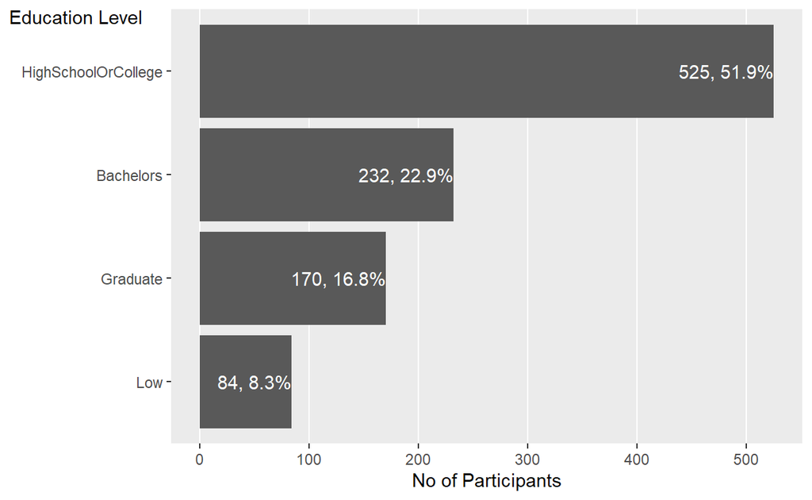

```r
ggplot(data=participants_data,
      aes(x=reorder(educationLevel,educationLevel,function(x)length(x))))+
  geom_bar() +
  coord_flip() +
  ylab("No of Participants") +
  xlab("Education Level") +
  theme(axis.title.y=element_text(angle =0,
                                  margin=margin(r=-70)),
        panel.grid.major.y = element_blank(),
        panel.grid.minor.y = element_blank(),
        panel.grid.minor.x = element_blank()) +
  geom_text(stat="count",
    aes(label=paste0(..count..,", ",
    round(..count../sum(..count..)*100,
      1),"%")),
    hjust=1,
    color = "white")
```

Though the graph provides an idea aboout the distribution of Education Level among the participants, the Education Levels can be considered ordinal with Low as the lowest level and graduate as the highest level. Let us view the above graph after fixing the order of the Education Level. We will also change the colors to go with the Age distribution histogram.

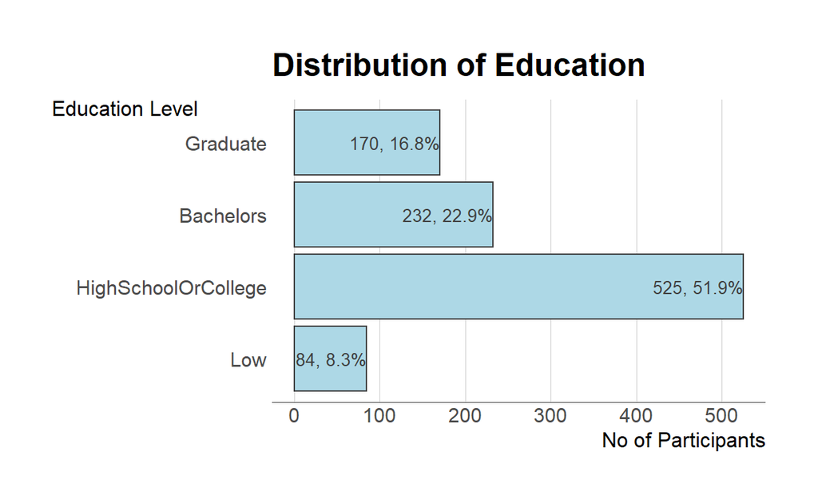

```r
level_order <- c('Low','HighSchoolOrCollege','Bachelors','Graduate')
p2 <- ggplot(data=participants_data,
      aes(x=factor(educationLevel,levels = level_order)))+
  geom_bar(color = "grey25",
           fill="light blue") +
  coord_flip() +
  ylab("No of Participants") +
  xlab("Education Level") +
  theme_ipsum(axis_title_size = 12, grid ="X")+
  theme(axis.title.y=element_text(angle =0,
                                  margin=margin(r=-70)),
        axis.line.x = element_line(color="grey25", size = 0.02)) +
  geom_text(stat="count",
    aes(label=paste0(..count..,", ",
    round(..count../sum(..count..)*100,
      1),"%")),
    hjust=1,
    color = "grey25",
    size=3.5)+
  ggtitle("Distribution of Education")

print(p2)
```

### Understanding the household size of participants

The below code chunk generates a bar graph indicating the distribution of household sizes among the participants.

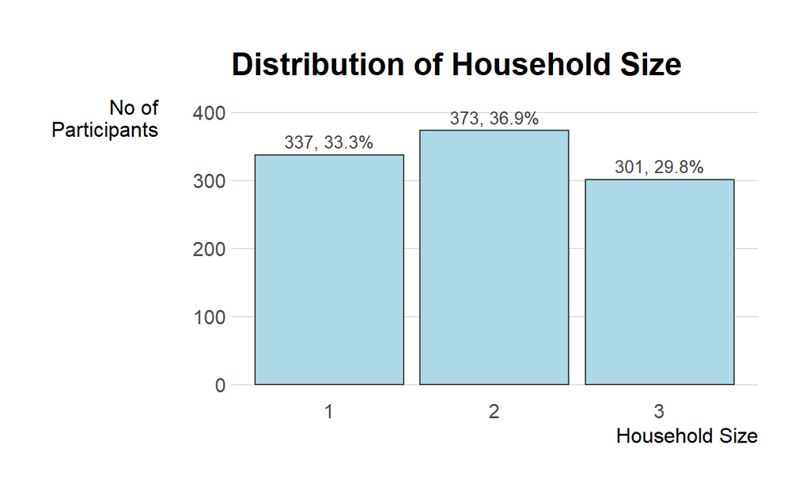

```r
p3 <- ggplot(data=participants_data,
      aes(x=householdSize))+
  geom_bar(color = "grey25",
           fill="light blue") +
  ylab("No of\nParticipants") +
  xlab("Household Size") +
  ylim(0,400) +
  theme_ipsum(axis_title_size = 12, grid ="Y")+
  theme(axis.title.y=element_text(angle =0,
                                  margin=margin(r=20))) +
  geom_text(stat="count",
    aes(label=paste0(..count..,", ",
    round(..count../sum(..count..)*100,
      1),"%")),
    vjust=-0.5,
    color = "grey25",
    size=3.5)+
  ggtitle("Distribution of Household Size")

print(p3)
```

### Understanding the participants with and without kids

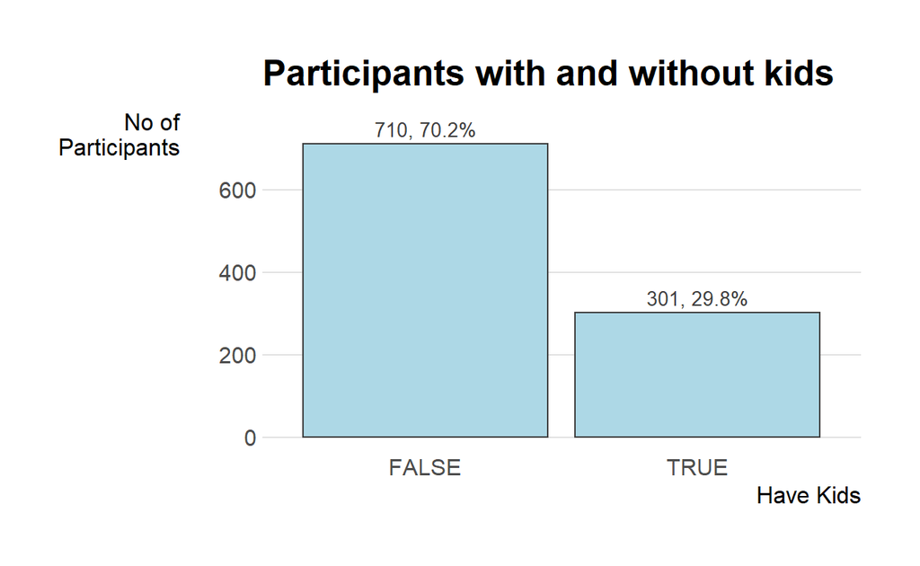

```r
p4 <- ggplot(data=participants_data,
      aes(x=haveKids))+
  geom_bar(color = "grey25",
           fill="light blue") +
  ylab("No of\nParticipants") +
  xlab("Have Kids") +
  ylim(0,750) +
  theme_ipsum(axis_title_size = 12, grid ="Y")+
  theme(axis.title.y=element_text(angle =0,
                                  margin=margin(r=20))) +
  geom_text(stat="count",
    aes(label=paste0(..count..,", ",
    round(..count../sum(..count..)*100,
      1),"%")),
    vjust=-0.5,
    color = "grey25",
    size=3.5)+
  ggtitle("Participants with and without kids")

print(p4)
```

### Understanding the joviality of participants

Let us understand the joviality distribution of participants using a density plot

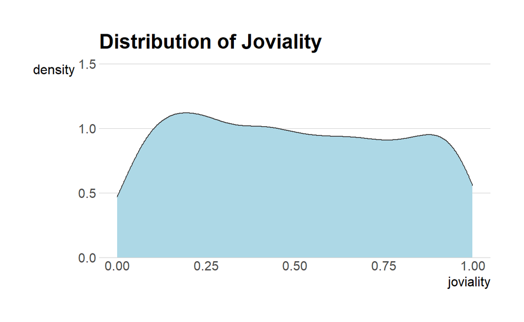

```r
p5 <- ggplot(participants_data,
       aes(x=joviality))+
  geom_density(color = "grey25",
               fill="light Blue")+
  ggtitle("Distribution of Joviality")+
  theme_ipsum(axis_title_size = 12, grid="Y")+
  theme(axis.title.y = element_text(angle=0))+
  scale_y_continuous(expand = c(0,0),limits = c(0,1.5))

print(p5)
```

### Understanding the joviality of participants with and without kids

From the Density plot below, we can see that more participants with kids have higher joviality than those without kids.

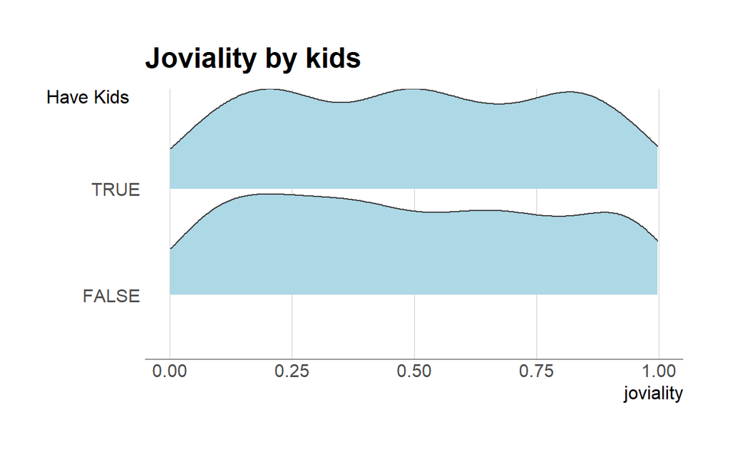

```r
ggplot(participants_data,
       aes(x = joviality, y = haveKids)) +
  geom_density_ridges(rel_min_height =0.01, scale = 0.95,
                    color = "grey25",
                    fill = "light blue")+
  ylab("Have Kids") +
  xlim(0,1)+
  theme_ipsum(axis_title_size = 12,
              grid = "X")+
  theme(axis.title.y=element_text(angle =0,
                                  margin=margin(r=-30)),
        axis.line.x = element_line(color="grey25", size = 0.02))+
  ggtitle("Joviality by kids")
```

### Understanding the joviality of participants by household size

From the Density plot below, we can see that more participants with 3 household members have higher joviality than those 2 or 1 members.

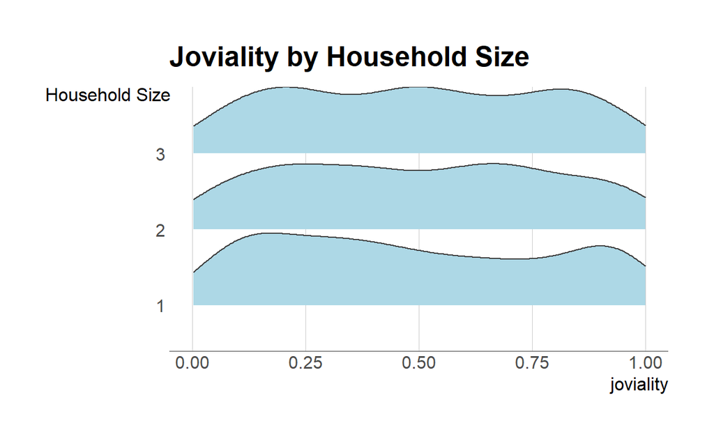

```r
ggplot(participants_data,
       aes(x = joviality, y = factor(householdSize))) +
  geom_density_ridges(rel_min_height =0.01, scale = 0.95,
                    color = "grey25",
                    fill = "light blue")+
  ylab("Household Size") +
  xlim(0,1)+
  theme_ipsum(axis_title_size = 12,
              grid = "X")+
  theme(axis.title.y=element_text(angle =0,
                                  margin=margin(r=-10)),
        axis.line.x = element_line(color="grey25", size = 0.02))+
  ggtitle("Joviality by Household Size")
```

Let us see if a violin plot gives more insights about joviality of participants from different household sizes. It is more obvious from violin plot that more participants with 3 household members have a higher joviality index.

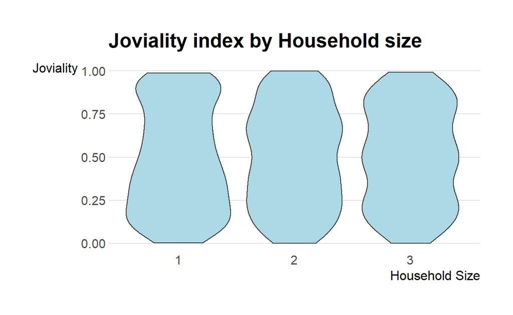

```r
p6 <- ggplot(data = participants_data,
  aes(y = joviality,
  x= factor(householdSize))) +
  geom_violin(color ="grey25",
              fill="light blue") +
  xlab("Household Size")+
  ylab("Joviality")+
  theme_ipsum(axis_title_size=12, grid ="Y")+
  theme(axis.title.y = element_text(angle=0))+
  ggtitle("Joviality index by Household size")
print(p6)
```

### Understanding the Interest Groups of Participants

We will use a bar chart to see if the Interest Group of Participants depends on whether they have kids or not. Plotting the no. of participants does not give us a true picture because from the previous visualizations, we have seen that almost 2/3rd of the participants do not have kids. Let us take a look at the same graph using percentage.

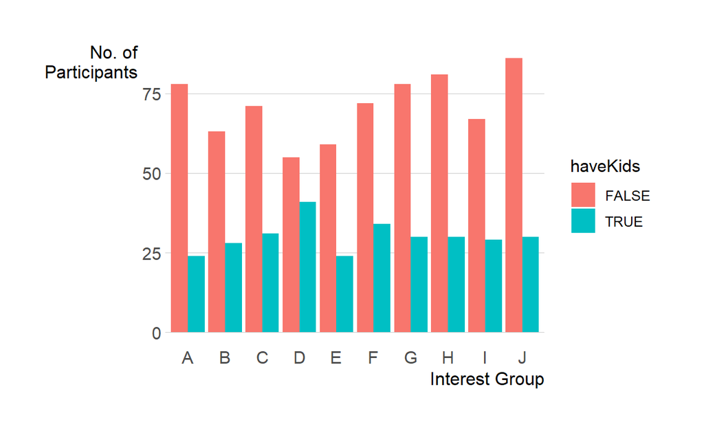

```r
ggplot(data=participants_data,
      aes(x=interestGroup, fill=haveKids))+
  geom_bar(position="dodge")+
  theme_ipsum(grid = "Y",axis_title_size =12)+
  ylab("No. of\nParticipants")+
  xlab("Interest Group")+
  theme(axis.title.y = element_text(angle=0))
```

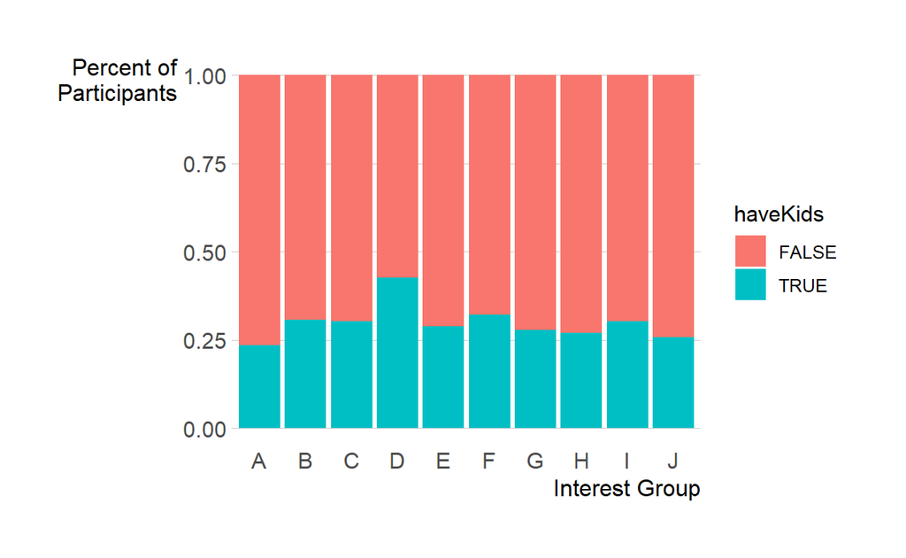

```r
ggplot(data=participants_data,
      aes(x=interestGroup, fill=haveKids))+
  geom_bar(position="fill")+
  theme_ipsum(grid = "Y",axis_title_size =12)+
  ylab("Percent of\nParticipants")+
  xlab("Interest Group")+
  theme(axis.title.y = element_text(angle=0))
```

# Conclusion

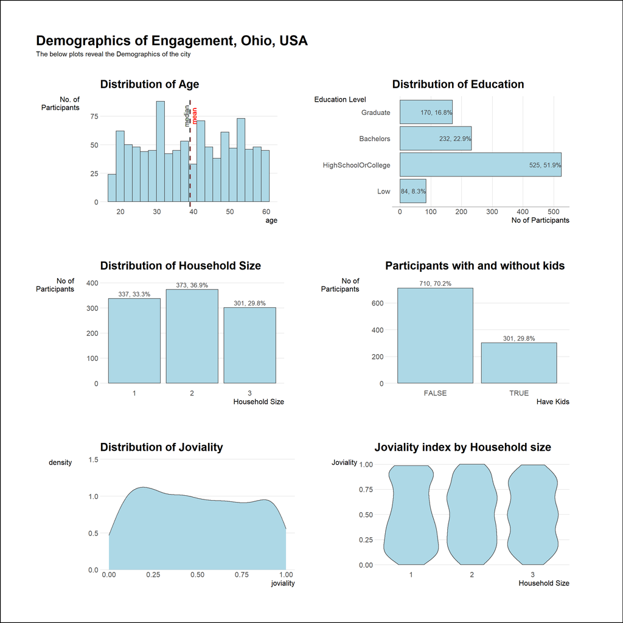

```r
patchwork <- (p1 + p2)/(p3 + p4)/(p5 + p6)
patchwork + plot_annotation(
  title = "Demographics of Engagement, Ohio, USA",
  subtitle = "The below plots reveal the Demographics of the city",
  theme = theme(plot.title = element_text(size = 22, face="bold"),
                plot.background = element_rect(fill = NA,
                                               colour = 'black',
                                               size = 1),
                plot.margin = margin(2,2,1,1,"cm"))
)
```